# Simple models

Sasha D. Hafner

14:23 - 26 March, 2026

# Structure/replication

Check for replication by slurry ID x trial ID. And number of digestate and raw slurries.

```r
table(ds[, .(slurry.ID, trial.ID)])
```

```
##           trial.ID
## slurry.ID  1 2 3 4 5
##   A        1 1 1 1 1
##   B        1 0 0 0 1
##   C        0 1 0 1 0
##   Cattle A 0 0 1 0 0
##   Cattle B 0 0 0 1 0
##   Cattle C 0 0 0 0 1
##   D        1 0 1 0 0
##   E        1 0 0 0 1
##   F        1 0 0 0 0
##   G        0 1 0 1 0
##   H        0 1 1 0 0
##   I        0 1 0 0 0
##   Pig A    0 0 1 0 0
##   Pig B    0 0 0 1 0
##   Pig C    0 0 0 0 1
```

```r
table(ds[, .(slurry.type, trial.ID)])
```

```
##            trial.ID
## slurry.type 1 2 3 4 5
##   Cattle    0 0 1 1 1
##   Digestate 5 5 3 3 3
##   Pig       0 0 1 1 1
```

# Exploratory plots and correlation

Scatterplots to look for correlation between emission and predictor variables and between predictor variables.

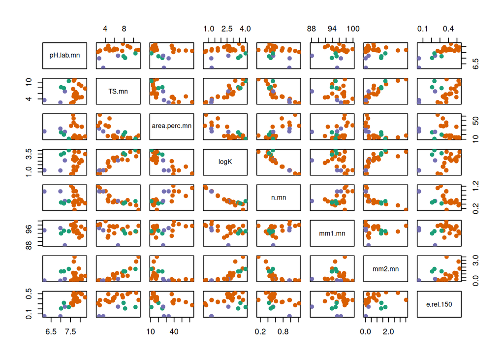

```r
pairs(ds[, .(pH.lab.mn, TS.mn, area.perc.mn, logK, n.mn, mm1.mn, mm2.mn, e.rel.150)], col = ds$col, pch = 19)
```

Pearson’s r. `dsd` is digestate only and `dsr` is raw slurry only. `ds` is everything.

```r
cor(ds[, .(pH.lab.mn, TS.mn, area.perc.mn, logK, n.mn, mm1.mn, mm2.mn, e.rel.150)])
```

```
##                pH.lab.mn      TS.mn area.perc.mn       logK       n.mn
## pH.lab.mn     1.00000000  0.1786702   -0.1044465  0.2225665 -0.2886527
## TS.mn         0.17867022  1.0000000   -0.6880913  0.8958075 -0.8493499
## area.perc.mn -0.10444651 -0.6880913    1.0000000 -0.7765801  0.7467723
## logK          0.22256650  0.8958075   -0.7765801  1.0000000 -0.9380515
## n.mn         -0.28865267 -0.8493499    0.7467723 -0.9380515  1.0000000
## mm1.mn        0.12164061 -0.2193676    0.2797694 -0.3177969  0.3499993
## mm2.mn        0.08648664  0.8787776   -0.5457961  0.7565176 -0.7567101
## e.rel.150     0.82476057  0.3925947   -0.3287758  0.3996005 -0.4956955
##                   mm1.mn      mm2.mn  e.rel.150
## pH.lab.mn     0.12164061  0.08648664  0.8247606
## TS.mn        -0.21936763  0.87877755  0.3925947
## area.perc.mn  0.27976942 -0.54579611 -0.3287758
## logK         -0.31779688  0.75651757  0.3996005
## n.mn          0.34999926 -0.75671010 -0.4956955
## mm1.mn        1.00000000 -0.01663415  0.0947383
## mm2.mn       -0.01663415  1.00000000  0.3291234
## e.rel.150     0.09473830  0.32912342  1.0000000
```

```r
cor(dsd[, .(pH.lab.mn, TS.mn, area.perc.mn, logK, n.mn, mm1.mn, mm2.mn, e.rel.150)])
```

```
##                pH.lab.mn      TS.mn area.perc.mn       logK       n.mn
## pH.lab.mn     1.00000000  0.2520898   -0.3171566  0.4096178 -0.3492866
## TS.mn         0.25208976  1.0000000   -0.6964706  0.8605593 -0.8542082
## area.perc.mn -0.31715665 -0.6964706    1.0000000 -0.8253694  0.7844272
## logK          0.40961775  0.8605593   -0.8253694  1.0000000 -0.9698918
## n.mn         -0.34928659 -0.8542082    0.7844272 -0.9698918  1.0000000
## mm1.mn       -0.49197855 -0.1991880    0.3574332 -0.3745096  0.4119694
## mm2.mn       -0.08639279  0.8847113   -0.5263077  0.7269647 -0.7485202
## e.rel.150     0.41066159  0.6703525   -0.6734704  0.7000221 -0.6630018
##                   mm1.mn      mm2.mn  e.rel.150
## pH.lab.mn    -0.49197855 -0.08639279  0.4106616
## TS.mn        -0.19918795  0.88471128  0.6703525
## area.perc.mn  0.35743320 -0.52630771 -0.6734704
## logK         -0.37450964  0.72696466  0.7000221
## n.mn          0.41196941 -0.74852016 -0.6630018
## mm1.mn        1.00000000 -0.07545152 -0.3553819
## mm2.mn       -0.07545152  1.00000000  0.4515068
## e.rel.150    -0.35538191  0.45150681  1.0000000
```

```r
cor(dsr[, .(pH.lab.mn, TS.mn, area.perc.mn, logK, n.mn, mm1.mn, mm2.mn, e.rel.150)])
```

```
##               pH.lab.mn      TS.mn area.perc.mn       logK       n.mn
## pH.lab.mn     1.0000000  0.6957636  -0.51018942  0.7309481 -0.7055283
## TS.mn         0.6957636  1.0000000  -0.88427786  0.9811468 -0.8878760
## area.perc.mn -0.5101894 -0.8842779   1.00000000 -0.8361804  0.6333115
## logK          0.7309481  0.9811468  -0.83618042  1.0000000 -0.9317904
## n.mn         -0.7055283 -0.8878760   0.63331149 -0.9317904  1.0000000
## mm1.mn       -0.2868310 -0.2168955  -0.02263719 -0.1609024  0.4091844
## mm2.mn        0.6125814  0.9235967  -0.83769762  0.9507644 -0.8036329
## e.rel.150     0.7082839  0.8261393  -0.64781280  0.8855748 -0.9617463
##                   mm1.mn     mm2.mn  e.rel.150
## pH.lab.mn    -0.28683098  0.6125814  0.7082839
## TS.mn        -0.21689551  0.9235967  0.8261393
## area.perc.mn -0.02263719 -0.8376976 -0.6478128
## logK         -0.16090242  0.9507644  0.8855748
## n.mn          0.40918435 -0.8036329 -0.9617463
## mm1.mn        1.00000000  0.1396064 -0.3952280
## mm2.mn        0.13960644  1.0000000  0.7388405
## e.rel.150    -0.39522795  0.7388405  1.0000000
```

Extract values for correlation with DM

```r
cor(ds[, .(pH.lab.mn, TS.mn, area.perc.mn, logK, n.mn, mm1.mn, mm2.mn, e.rel.150)])[, 'TS.mn']
```

```
##    pH.lab.mn        TS.mn area.perc.mn         logK         n.mn       mm1.mn
##    0.1786702    1.0000000   -0.6880913    0.8958075   -0.8493499   -0.2193676
##       mm2.mn    e.rel.150
##    0.8787776    0.3925947
```

# Models - combined slurry types

## A. Slurry type models

```r
lm_a1 <- lm(e.rel.150 ~ slurry.type, data = ds)
summary(lm_a1)
```

```
##
## Call:
## lm(formula = e.rel.150 ~ slurry.type, data = ds)
##
## Residuals:
##      Min       1Q   Median       3Q      Max
## -0.13695 -0.05795 -0.01900  0.06500  0.12690
##
## Coefficients:
##                      Estimate Std. Error t value Pr(>|t|)
## (Intercept)           0.25400    0.04457   5.699 9.87e-06 ***
## slurry.typeDigestate  0.15595    0.04796   3.252  0.00366 **
## slurry.typePig       -0.13790    0.06303  -2.188  0.03958 *
## ---
## Signif. codes:  0 '***' 0.001 '**' 0.01 '*' 0.05 '.' 0.1 ' ' 1
##
## Residual standard error: 0.07719 on 22 degrees of freedom
## Multiple R-squared:  0.6641, Adjusted R-squared:  0.6336
## F-statistic: 21.75 on 2 and 22 DF,  p-value: 6.143e-06
```

```r
drop1(lm_a1, test = 'F')
```

```
## Single term deletions
##
## Model:
## e.rel.150 ~ slurry.type
##             Df Sum of Sq     RSS     AIC F value    Pr(>F)
## <none>                   0.13109 -125.27
## slurry.type  2   0.25916 0.39025 -102.00  21.747 6.143e-06 ***
## ---
## Signif. codes:  0 '***' 0.001 '**' 0.01 '*' 0.05 '.' 0.1 ' ' 1
```

```r
mm_a1 <- lmer(e.rel.150 ~ slurry.type + (1|trial.ID) + (1|slurry.ID), data = ds, REML = FALSE)
summary(mm_a1)
```

```
## Linear mixed model fit by maximum likelihood  ['lmerMod']
## Formula: e.rel.150 ~ slurry.type + (1 | trial.ID) + (1 | slurry.ID)
##    Data: ds
##
##       AIC       BIC    logLik -2*log(L)  df.resid
##     -49.0     -41.6      30.5     -61.0        19
##
## Scaled residuals:
##     Min      1Q  Median      3Q     Max
## -1.4446 -0.7259 -0.1416  0.7901  1.7619
##
## Random effects:
##  Groups    Name        Variance  Std.Dev.
##  slurry.ID (Intercept) 0.0007702 0.02775
##  trial.ID  (Intercept) 0.0005169 0.02274
##  Residual              0.0039776 0.06307
## Number of obs: 25, groups:  slurry.ID, 15; trial.ID, 5
##
## Fixed effects:
##                      Estimate Std. Error t value
## (Intercept)           0.26428    0.04162   6.350
## slurry.typeDigestate  0.14811    0.04447   3.331
## slurry.typePig       -0.13790    0.05626  -2.451
##
## Correlation of Fixed Effects:
##             (Intr) slrr.D
## slrry.typDg -0.889
## slrry.typPg -0.676  0.633
```

```r
fixef(mm_a1)
```

```
##          (Intercept) slurry.typeDigestate       slurry.typePig
##            0.2642768            0.1481121           -0.1379000
```

```r
drop1(mm_a1, test = 'Chisq')
```

```
## Single term deletions
##
## Model:
## e.rel.150 ~ slurry.type + (1 | trial.ID) + (1 | slurry.ID)
##             npar     AIC    LRT   Pr(Chi)
## <none>           -48.953
## slurry.type    2 -30.368 22.585 1.247e-05 ***
## ---
## Signif. codes:  0 '***' 0.001 '**' 0.01 '*' 0.05 '.' 0.1 ' ' 1
```

```r
r2(mm_a1)
```

```
## # R2 for Mixed Models
##
##   Conditional R2: 0.742
##      Marginal R2: 0.658
```

Exclude intercept to get means.

```r
mm_a2 <- lmer(e.rel.150 ~ slurry.type + (1|trial.ID) + (1|slurry.ID) - 1, data = ds, REML = FALSE)
summary(mm_a2)
```

```
## Linear mixed model fit by maximum likelihood  ['lmerMod']
## Formula: e.rel.150 ~ slurry.type + (1 | trial.ID) + (1 | slurry.ID) -      1
##    Data: ds
##
##       AIC       BIC    logLik -2*log(L)  df.resid
##     -49.0     -41.6      30.5     -61.0        19
##
## Scaled residuals:
##     Min      1Q  Median      3Q     Max
## -1.4446 -0.7259 -0.1416  0.7901  1.7619
##
## Random effects:
##  Groups    Name        Variance  Std.Dev.
##  slurry.ID (Intercept) 0.0007702 0.02775
##  trial.ID  (Intercept) 0.0005169 0.02274
##  Residual              0.0039776 0.06307
## Number of obs: 25, groups:  slurry.ID, 15; trial.ID, 5
##
## Fixed effects:
##                      Estimate Std. Error t value
## slurry.typeCattle     0.26428    0.04162   6.350
## slurry.typeDigestate  0.41239    0.02046  20.156
## slurry.typePig        0.12638    0.04162   3.037
##
## Correlation of Fixed Effects:
##             slrr.C slrr.D
## slrry.typDg 0.102
## slrry.typPg 0.086  0.102
```

```r
fixef(mm_a2)
```

```
##    slurry.typeCattle slurry.typeDigestate       slurry.typePig
##            0.2642768            0.4123890            0.1263768
```

```r
drop1(mm_a2, test = 'Chisq')
```

```
## Single term deletions
##
## Model:
## e.rel.150 ~ slurry.type + (1 | trial.ID) + (1 | slurry.ID) -
##     1
##             npar     AIC    LRT   Pr(Chi)
## <none>           -48.953
## slurry.type    2 -30.368 22.585 1.247e-05 ***
## ---
## Signif. codes:  0 '***' 0.001 '**' 0.01 '*' 0.05 '.' 0.1 ' ' 1
```

```r
r2(mm_a2)
```

```
## # R2 for Mixed Models
##
##   Conditional R2: 0.742
##      Marginal R2: 0.658
```

Save to list.

```r
modlist <- list()
modlist[['a']] <- mm_a2
```

```r
lm_a2 <- lm(e.rel.150 ~ slurry.type + trial.ID, data = ds)
summary(lm_a2)
```

```
##
## Call:
## lm(formula = e.rel.150 ~ slurry.type + trial.ID, data = ds)
##
## Residuals:
##       Min        1Q    Median        3Q       Max
## -0.098600 -0.050600 -0.004733  0.054400  0.141720
##
## Coefficients:
##                      Estimate Std. Error t value Pr(>|t|)
## (Intercept)           0.35127    0.05850   6.005 1.12e-05 ***
## slurry.typeDigestate  0.11333    0.04858   2.333   0.0314 *
## slurry.typePig       -0.13790    0.05950  -2.318   0.0324 *
## trial.ID2            -0.03260    0.04608  -0.707   0.4884
## trial.ID3            -0.11209    0.04858  -2.307   0.0331 *
## trial.ID4            -0.08587    0.04858  -1.768   0.0941 .
## trial.ID5            -0.09385    0.04858  -1.932   0.0693 .
## ---
## Signif. codes:  0 '***' 0.001 '**' 0.01 '*' 0.05 '.' 0.1 ' ' 1
##
## Residual standard error: 0.07287 on 18 degrees of freedom
## Multiple R-squared:  0.7551, Adjusted R-squared:  0.6735
## F-statistic:  9.25 on 6 and 18 DF,  p-value: 0.000106
```

```r
drop1(lm_a2, test = 'F')
```

```
## Single term deletions
##
## Model:
## e.rel.150 ~ slurry.type + trial.ID
##             Df Sum of Sq      RSS     AIC F value    Pr(>F)
## <none>                   0.095571 -125.17
## slurry.type  2  0.148143 0.243713 -105.77 13.9507 0.0002193 ***
## trial.ID     4  0.035516 0.131087 -125.27  1.6723 0.2001013
## ---
## Signif. codes:  0 '***' 0.001 '**' 0.01 '*' 0.05 '.' 0.1 ' ' 1
```

```r
lm_a3 <- aov(e.rel.150 ~ slurry.type, data = ds)
summary(lm_a3)
```

```
##             Df Sum Sq Mean Sq F value   Pr(>F)
## slurry.type  2 0.2592 0.12958   21.75 6.14e-06 ***
## Residuals   22 0.1311 0.00596
## ---
## Signif. codes:  0 '***' 0.001 '**' 0.01 '*' 0.05 '.' 0.1 ' ' 1
```

```r
model.tables(lm_a3, type = 'means')
```

```
## Tables of means
## Grand mean
##
## 0.355972
##
##  slurry.type
##     Cattle Digestate    Pig
##      0.254    0.4099 0.1161
## rep  3.000   19.0000 3.0000
```

```r
TukeyHSD(lm_a3, 'slurry.type')
```

```
##   Tukey multiple comparisons of means
##     95% family-wise confidence level
##
## Fit: aov(formula = e.rel.150 ~ slurry.type, data = ds)
##
## $slurry.type
##                        diff         lwr        upr     p adj
## Digestate-Cattle  0.1559474  0.03547904  0.2764157 0.0098209
## Pig-Cattle       -0.1379000 -0.29622640  0.0204264 0.0955805
## Pig-Digestate    -0.2938474 -0.41431570 -0.1733790 0.0000105
```

## B. DM and pH

Hypothesize that DM and pH can explain emission. `mm1.mn` is the only other variable not highly correlated with DM, so we include that too.

```r
mm_b1 <- lmer(e.rel.150 ~ TS.mn + pH.lab.mn + mm1.mn + (1|trial.ID) + (1|slurry.ID), data = ds, REML = FALSE)
```

```
## boundary (singular) fit: see help('isSingular')
```

```r
summary(mm_b1)
```

```
## Linear mixed model fit by maximum likelihood  ['lmerMod']
## Formula: e.rel.150 ~ TS.mn + pH.lab.mn + mm1.mn + (1 | trial.ID) + (1 |
##     slurry.ID)
##    Data: ds
##
##       AIC       BIC    logLik -2*log(L)  df.resid
##     -54.0     -45.5      34.0     -68.0        18
##
## Scaled residuals:
##      Min       1Q   Median       3Q      Max
## -1.99902 -0.59351  0.09668  0.80179  1.35513
##
## Random effects:
##  Groups    Name        Variance  Std.Dev.
##  slurry.ID (Intercept) 0.0000000 0.00000
##  trial.ID  (Intercept) 0.0006603 0.02570
##  Residual              0.0033665 0.05802
## Number of obs: 25, groups:  slurry.ID, 15; trial.ID, 5
##
## Fixed effects:
##              Estimate Std. Error t value
## (Intercept) -1.618599   0.509745  -3.175
## TS.mn        0.011218   0.005010   2.239
## pH.lab.mn    0.215087   0.029250   7.353
## mm1.mn       0.002820   0.005149   0.548
##
## Correlation of Fixed Effects:
##           (Intr) TS.mn  pH.lb.
## TS.mn     -0.224
## pH.lab.mn -0.251 -0.198
## mm1.mn    -0.905  0.258 -0.178
## optimizer (nloptwrap) convergence code: 0 (OK)
## boundary (singular) fit: see help('isSingular')
```

```r
fixef(mm_b1)
```

```
##  (Intercept)        TS.mn    pH.lab.mn       mm1.mn
## -1.618598669  0.011218414  0.215086675  0.002819881
```

```r
drop1(mm_b1, test = 'Chisq')
```

```
## boundary (singular) fit: see help('isSingular')
## boundary (singular) fit: see help('isSingular')
```

```
## Single term deletions
##
## Model:
## e.rel.150 ~ TS.mn + pH.lab.mn + mm1.mn + (1 | trial.ID) + (1 |
##     slurry.ID)
##           npar     AIC    LRT   Pr(Chi)
## <none>         -53.983
## TS.mn        1 -51.596  4.387   0.03621 *
## pH.lab.mn    1 -31.493 24.490 7.468e-07 ***
## mm1.mn       1 -55.685  0.298   0.58513
## ---
## Signif. codes:  0 '***' 0.001 '**' 0.01 '*' 0.05 '.' 0.1 ' ' 1
```

```r
r2(mm_b1)
```

```
## Random effect variances not available. Returned R2 does not account for random effects.
```

```
## # R2 for Mixed Models
##
##   Conditional R2: NA
##      Marginal R2: 0.760
```

Drop slurry ID.

```r
mm_b2 <- lmer(e.rel.150 ~ TS.mn + pH.lab.mn + mm1.mn + (1|trial.ID), data = ds, REML = FALSE)
summary(mm_b2)
```

```
## Linear mixed model fit by maximum likelihood  ['lmerMod']
## Formula: e.rel.150 ~ TS.mn + pH.lab.mn + mm1.mn + (1 | trial.ID)
##    Data: ds
##
##       AIC       BIC    logLik -2*log(L)  df.resid
##     -56.0     -48.7      34.0     -68.0        19
##
## Scaled residuals:
##      Min       1Q   Median       3Q      Max
## -1.99902 -0.59351  0.09668  0.80179  1.35513
##
## Random effects:
##  Groups   Name        Variance  Std.Dev.
##  trial.ID (Intercept) 0.0006603 0.02570
##  Residual             0.0033665 0.05802
## Number of obs: 25, groups:  trial.ID, 5
##
## Fixed effects:
##              Estimate Std. Error t value
## (Intercept) -1.618599   0.509745  -3.175
## TS.mn        0.011218   0.005010   2.239
## pH.lab.mn    0.215087   0.029250   7.353
## mm1.mn       0.002820   0.005149   0.548
##
## Correlation of Fixed Effects:
##           (Intr) TS.mn  pH.lb.
## TS.mn     -0.224
## pH.lab.mn -0.251 -0.198
## mm1.mn    -0.905  0.258 -0.178
```

```r
fixef(mm_b2)
```

```
##  (Intercept)        TS.mn    pH.lab.mn       mm1.mn
## -1.618598669  0.011218414  0.215086675  0.002819881
```

```r
drop1(mm_b2, test = 'Chisq')
```

```
## Single term deletions
##
## Model:
## e.rel.150 ~ TS.mn + pH.lab.mn + mm1.mn + (1 | trial.ID)
##           npar     AIC    LRT   Pr(Chi)
## <none>         -55.983
## TS.mn        1 -53.596  4.387   0.03621 *
## pH.lab.mn    1 -29.196 28.787 8.079e-08 ***
## mm1.mn       1 -57.685  0.298   0.58513
## ---
## Signif. codes:  0 '***' 0.001 '**' 0.01 '*' 0.05 '.' 0.1 ' ' 1
```

```r
r2(mm_b2)
```

```
## # R2 for Mixed Models
##
##   Conditional R2: 0.771
##      Marginal R2: 0.726
```

No evidence of `mm1.mn` correlation so we’ll drop it.

```r
mm_b3 <- lmer(e.rel.150 ~ TS.mn + pH.lab.mn + (1|trial.ID), data = ds, REML = FALSE)
summary(mm_b3)
```

```
## Linear mixed model fit by maximum likelihood  ['lmerMod']
## Formula: e.rel.150 ~ TS.mn + pH.lab.mn + (1 | trial.ID)
##    Data: ds
##
##       AIC       BIC    logLik -2*log(L)  df.resid
##     -57.7     -51.6      33.8     -67.7        20
##
## Scaled residuals:
##      Min       1Q   Median       3Q      Max
## -1.97516 -0.57216 -0.00941  0.76596  1.37086
##
## Random effects:
##  Groups   Name        Variance  Std.Dev.
##  trial.ID (Intercept) 0.0006779 0.02604
##  Residual             0.0034014 0.05832
## Number of obs: 25, groups:  trial.ID, 5
##
## Fixed effects:
##              Estimate Std. Error t value
## (Intercept) -1.365074   0.217846  -6.266
## TS.mn        0.010491   0.004867   2.156
## pH.lab.mn    0.217850   0.028939   7.528
##
## Correlation of Fixed Effects:
##           (Intr) TS.mn
## TS.mn      0.023
## pH.lab.mn -0.988 -0.159
```

```r
fixef(mm_b3)
```

```
## (Intercept)       TS.mn   pH.lab.mn
## -1.36507351  0.01049142  0.21784998
```

```r
drop1(mm_b3, test = 'Chisq')
```

```
## Single term deletions
##
## Model:
## e.rel.150 ~ TS.mn + pH.lab.mn + (1 | trial.ID)
##           npar     AIC     LRT  Pr(Chi)
## <none>         -57.685
## TS.mn        1 -55.596  4.0894  0.04315 *
## pH.lab.mn    1 -30.092 29.5930 5.33e-08 ***
## ---
## Signif. codes:  0 '***' 0.001 '**' 0.01 '*' 0.05 '.' 0.1 ' ' 1
```

```r
r2(mm_b3)
```

```
## # R2 for Mixed Models
##
##   Conditional R2: 0.768
##      Marginal R2: 0.722
```

Save.

```r
modlist[['b']] <- mm_b3
```

Pretty clear, and positive coefficients.

Check linear model.

```r
lm_b3 <- lm(e.rel.150 ~ TS.mn + pH.lab.mn, data = ds)
summary(lm_b3)
```

```
##
## Call:
## lm(formula = e.rel.150 ~ TS.mn + pH.lab.mn, data = ds)
##
## Residuals:
##       Min        1Q    Median        3Q       Max
## -0.131242 -0.047022  0.005173  0.046415  0.096104
##
## Coefficients:
##              Estimate Std. Error t value Pr(>|t|)
## (Intercept) -1.459564   0.241792  -6.036 4.48e-06 ***
## TS.mn        0.012597   0.005469   2.303   0.0311 *
## pH.lab.mn    0.228563   0.032250   7.087 4.15e-07 ***
## ---
## Signif. codes:  0 '***' 0.001 '**' 0.01 '*' 0.05 '.' 0.1 ' ' 1
##
## Residual standard error: 0.0676 on 22 degrees of freedom
## Multiple R-squared:  0.7424, Adjusted R-squared:  0.7189
## F-statistic: 31.69 on 2 and 22 DF,  p-value: 3.321e-07
```

Same.

Add slurry type.

```r
mm_b4 <- lmer(e.rel.150 ~ TS.mn + pH.lab.mn + slurry.type + (1|trial.ID), data = ds, REML = FALSE)
```

```
## boundary (singular) fit: see help('isSingular')
```

```r
summary(mm_b4)
```

```
## Linear mixed model fit by maximum likelihood  ['lmerMod']
## Formula: e.rel.150 ~ TS.mn + pH.lab.mn + slurry.type + (1 | trial.ID)
##    Data: ds
##
##       AIC       BIC    logLik -2*log(L)  df.resid
##     -63.5     -54.9      38.7     -77.5        18
##
## Scaled residuals:
##      Min       1Q   Median       3Q      Max
## -2.25823 -0.84156  0.08986  0.73870  1.66827
##
## Random effects:
##  Groups   Name        Variance Std.Dev.
##  trial.ID (Intercept) 0.000000 0.00000
##  Residual             0.002643 0.05141
## Number of obs: 25, groups:  trial.ID, 5
##
## Fixed effects:
##                       Estimate Std. Error t value
## (Intercept)          -0.540706   0.328317  -1.647
## TS.mn                 0.018365   0.004783   3.839
## pH.lab.mn             0.087914   0.046804   1.878
## slurry.typeDigestate  0.153677   0.046809   3.283
## slurry.typePig       -0.018753   0.048557  -0.386
##
## Correlation of Fixed Effects:
##             (Intr) TS.mn  pH.lb. slrr.D
## TS.mn        0.172
## pH.lab.mn   -0.988 -0.293
## slrry.typDg  0.582  0.455 -0.680
## slrry.typPg -0.374  0.326  0.270  0.317
## optimizer (nloptwrap) convergence code: 0 (OK)
## boundary (singular) fit: see help('isSingular')
```

```r
fixef(mm_b4)
```

```
##          (Intercept)                TS.mn            pH.lab.mn
##          -0.54070648           0.01836544           0.08791383
## slurry.typeDigestate       slurry.typePig
##           0.15367657          -0.01875290
```

```r
drop1(mm_b4, test = 'Chisq')
```

```
## boundary (singular) fit: see help('isSingular')
```

```
## Single term deletions
##
## Model:
## e.rel.150 ~ TS.mn + pH.lab.mn + slurry.type + (1 | trial.ID)
##             npar     AIC     LRT  Pr(Chi)
## <none>           -63.451
## TS.mn          1 -54.890 10.5607 0.001155 **
## pH.lab.mn      1 -62.151  3.3004 0.069261 .
## slurry.type    2 -57.685  9.7659 0.007575 **
## ---
## Signif. codes:  0 '***' 0.001 '**' 0.01 '*' 0.05 '.' 0.1 ' ' 1
```

```r
anova(mm_b4, mm_b3, test = 'Chisq')
```

```
## Data: ds
## Models:
## mm_b3: e.rel.150 ~ TS.mn + pH.lab.mn + (1 | trial.ID)
## mm_b4: e.rel.150 ~ TS.mn + pH.lab.mn + slurry.type + (1 | trial.ID)
##       npar     AIC     BIC logLik -2*log(L)  Chisq Df Pr(>Chisq)
## mm_b3    5 -57.685 -51.591 33.843   -67.685
## mm_b4    7 -63.451 -54.919 38.726   -77.451 9.7659  2   0.007575 **
## ---
## Signif. codes:  0 '***' 0.001 '**' 0.01 '*' 0.05 '.' 0.1 ' ' 1
```

```r
r2(mm_b4)
```

```
## Random effect variances not available. Returned R2 does not account for random effects.
```

```
## # R2 for Mixed Models
##
##   Conditional R2: NA
##      Marginal R2: 0.836
```

```r
AIC(mm_b4)
```

```
## [1] -63.45104
```

```r
AIC(mm_b3)
```

```
## [1] -57.68515
```

```r
model_performance(mm_b4, estimator = 'ML')
```

```
## Random effect variances not available. Returned R2 does not account for random effects.
```

```
## # Indices of model performance
##
## AIC   |  AICc |   BIC | R2 (cond.) | R2 (marg.) |  RMSE | Sigma
## ---------------------------------------------------------------
## -63.5 | -56.9 | -54.9 |            |      0.836 | 0.051 | 0.051
```

```r
model_performance(mm_b3, estimator = 'ML')
```

```
## # Indices of model performance
##
## AIC   |  AICc |   BIC | R2 (cond.) | R2 (marg.) |   ICC |  RMSE | Sigma
## -----------------------------------------------------------------------
## -57.7 | -54.5 | -51.6 |      0.768 |      0.722 | 0.166 | 0.055 | 0.058
```

Save

```r
modlist[['b+']] <- mm_b4
```

And try linear model with slurry type too.

```r
lm_b4 <- lm(e.rel.150 ~ TS.mn + pH.lab.mn + slurry.type, data = ds)
summary(lm_b4)
```

```
##
## Call:
## lm(formula = e.rel.150 ~ TS.mn + pH.lab.mn + slurry.type, data = ds)
##
## Residuals:
##      Min       1Q   Median       3Q      Max
## -0.11609 -0.04326  0.00462  0.03798  0.08576
##
## Coefficients:
##                       Estimate Std. Error t value Pr(>|t|)
## (Intercept)          -0.540706   0.367069  -1.473  0.15631
## TS.mn                 0.018365   0.005348   3.434  0.00263 **
## pH.lab.mn             0.087914   0.052328   1.680  0.10850
## slurry.typeDigestate  0.153677   0.052334   2.936  0.00816 **
## slurry.typePig       -0.018753   0.054288  -0.345  0.73338
## ---
## Signif. codes:  0 '***' 0.001 '**' 0.01 '*' 0.05 '.' 0.1 ' ' 1
##
## Residual standard error: 0.05748 on 20 degrees of freedom
## Multiple R-squared:  0.8307, Adjusted R-squared:  0.7968
## F-statistic: 24.53 on 4 and 20 DF,  p-value: 1.801e-07
```

```r
drop1(lm_b4, test = 'F')
```

```
## Single term deletions
##
## Model:
## e.rel.150 ~ TS.mn + pH.lab.mn + slurry.type
##             Df Sum of Sq      RSS     AIC F value   Pr(>F)
## <none>                   0.066070 -138.40
## TS.mn        1  0.038956 0.105026 -128.81 11.7924 0.002627 **
## pH.lab.mn    1  0.009324 0.075394 -137.10  2.8226 0.108501
## slurry.type  2  0.034477 0.100547 -131.90  5.2183 0.015009 *
## ---
## Signif. codes:  0 '***' 0.001 '**' 0.01 '*' 0.05 '.' 0.1 ' ' 1
```

```r
summary(lm_a1)[c('r.squared', 'adj.r.squared')]
```

```
## $r.squared
## [1] 0.6640958
##
## $adj.r.squared
## [1] 0.633559
```

```r
summary(lm_b3)[c('r.squared', 'adj.r.squared')]
```

```
## $r.squared
## [1] 0.7423531
##
## $adj.r.squared
## [1] 0.7189307
```

```r
summary(lm_b4)[c('r.squared', 'adj.r.squared')]
```

```
## $r.squared
## [1] 0.8306991
##
## $adj.r.squared
## [1] 0.7968389
```

Similar model

```r
lm_b5 <- aov(e.rel.150 ~ TS.mn + pH.lab.mn + slurry.type, data = ds)
pairs(emmeans(lm_b5, ~ slurry.type), adjust = 'tukey')
```

```
##  contrast           estimate     SE df t.ratio p.value
##  Cattle - Digestate  -0.1537 0.0523 20  -2.936  0.0213
##  Cattle - Pig         0.0188 0.0543 20   0.345  0.9365
##  Digestate - Pig      0.1724 0.0623 20   2.767  0.0306
##
## P value adjustment: tukey method for comparing a family of 3 estimates
```

```r
predict(lm_b5, newdata = data.frame(TS.mn = mean(ds$TS.mn), pH.lab.mn = mean(ds$pH.lab.mn), slurry.type = c('Cattle', 'Pig', 'Digestate')))
```

```
##         1         2         3
## 0.2414282 0.2226753 0.3951047
```

# C. ESA based models

```r
mm_c1 <- lmer(e.rel.150 ~ area.perc.mn + pH.lab.mn + mm1.mn + mm2.mn + (1|trial.ID) + (1|slurry.ID), data = ds, REML = FALSE)
```

```
## boundary (singular) fit: see help('isSingular')
```

```r
summary(mm_c1)
```

```
## Linear mixed model fit by maximum likelihood  ['lmerMod']
## Formula: e.rel.150 ~ area.perc.mn + pH.lab.mn + mm1.mn + mm2.mn + (1 |
##     trial.ID) + (1 | slurry.ID)
##    Data: ds
##
##       AIC       BIC    logLik -2*log(L)  df.resid
##     -53.2     -43.4      34.6     -69.2        17
##
## Scaled residuals:
##     Min      1Q  Median      3Q     Max
## -2.1849 -0.4870  0.1665  0.7667  1.3905
##
## Random effects:
##  Groups    Name        Variance Std.Dev.
##  slurry.ID (Intercept) 0.000000 0.00000
##  trial.ID  (Intercept) 0.000000 0.00000
##  Residual              0.003676 0.06063
## Number of obs: 25, groups:  slurry.ID, 15; trial.ID, 5
##
## Fixed effects:
##               Estimate Std. Error t value
## (Intercept)  -1.619914   0.518998  -3.121
## area.perc.mn -0.001473   0.001087  -1.356
## pH.lab.mn     0.230655   0.028980   7.959
## mm1.mn        0.002517   0.005374   0.468
## mm2.mn        0.023958   0.016492   1.453
##
## Correlation of Fixed Effects:
##             (Intr) ar.pr. pH.lb. mm1.mn
## area.prc.mn  0.215
## pH.lab.mn   -0.277  0.116
## mm1.mn      -0.904 -0.335 -0.154
## mm2.mn       0.112  0.559 -0.009 -0.166
## optimizer (nloptwrap) convergence code: 0 (OK)
## boundary (singular) fit: see help('isSingular')
```

```r
fixef(mm_c1)
```

```
##  (Intercept) area.perc.mn    pH.lab.mn       mm1.mn       mm2.mn
## -1.619913640 -0.001473094  0.230655055  0.002516986  0.023957593
```

```r
drop1(mm_c1, test = 'Chisq')
```

```
## boundary (singular) fit: see help('isSingular')
## boundary (singular) fit: see help('isSingular')
## boundary (singular) fit: see help('isSingular')
```

```
## Single term deletions
##
## Model:
## e.rel.150 ~ area.perc.mn + pH.lab.mn + mm1.mn + mm2.mn + (1 |
##     trial.ID) + (1 | slurry.ID)
##              npar     AIC     LRT   Pr(Chi)
## <none>            -53.200
## area.perc.mn    1 -53.890  1.3101    0.2524
## pH.lab.mn       1 -27.078 28.1217 1.139e-07 ***
## mm1.mn          1 -54.982  0.2184    0.6403
## mm2.mn          1 -53.174  2.0260    0.1546
## ---
## Signif. codes:  0 '***' 0.001 '**' 0.01 '*' 0.05 '.' 0.1 ' ' 1
```

```r
r2(mm_c1)
```

```
## Random effect variances not available. Returned R2 does not account for random effects.
```

```
## # R2 for Mixed Models
##
##   Conditional R2: NA
##      Marginal R2: 0.772
```

Drop slurry ID.

```r
mm_c2 <- lmer(e.rel.150 ~ area.perc.mn + pH.lab.mn + mm1.mn + mm2.mn + (1|trial.ID), data = ds, REML = FALSE)
```

```
## boundary (singular) fit: see help('isSingular')
```

```r
summary(mm_c2)
```

```
## Linear mixed model fit by maximum likelihood  ['lmerMod']
## Formula: e.rel.150 ~ area.perc.mn + pH.lab.mn + mm1.mn + mm2.mn + (1 |
##     trial.ID)
##    Data: ds
##
##       AIC       BIC    logLik -2*log(L)  df.resid
##     -55.2     -46.7      34.6     -69.2        18
##
## Scaled residuals:
##     Min      1Q  Median      3Q     Max
## -2.1849 -0.4870  0.1665  0.7667  1.3905
##
## Random effects:
##  Groups   Name        Variance Std.Dev.
##  trial.ID (Intercept) 0.000000 0.00000
##  Residual             0.003676 0.06063
## Number of obs: 25, groups:  trial.ID, 5
##
## Fixed effects:
##               Estimate Std. Error t value
## (Intercept)  -1.619914   0.518998  -3.121
## area.perc.mn -0.001473   0.001087  -1.356
## pH.lab.mn     0.230655   0.028980   7.959
## mm1.mn        0.002517   0.005374   0.468
## mm2.mn        0.023958   0.016492   1.453
##
## Correlation of Fixed Effects:
##             (Intr) ar.pr. pH.lb. mm1.mn
## area.prc.mn  0.215
## pH.lab.mn   -0.277  0.116
## mm1.mn      -0.904 -0.335 -0.154
## mm2.mn       0.112  0.559 -0.009 -0.166
## optimizer (nloptwrap) convergence code: 0 (OK)
## boundary (singular) fit: see help('isSingular')
```

```r
fixef(mm_c2)
```

```
##  (Intercept) area.perc.mn    pH.lab.mn       mm1.mn       mm2.mn
## -1.619913640 -0.001473094  0.230655055  0.002516986  0.023957593
```

```r
drop1(mm_c2, test = 'Chisq')
```

```
## boundary (singular) fit: see help('isSingular')
## boundary (singular) fit: see help('isSingular')
```

```
## Single term deletions
##
## Model:
## e.rel.150 ~ area.perc.mn + pH.lab.mn + mm1.mn + mm2.mn + (1 |
##     trial.ID)
##              npar     AIC     LRT  Pr(Chi)
## <none>            -55.200
## area.perc.mn    1 -55.890  1.3101   0.2524
## pH.lab.mn       1 -25.696 31.5045 1.99e-08 ***
## mm1.mn          1 -56.982  0.2184   0.6403
## mm2.mn          1 -55.174  2.0260   0.1546
## ---
## Signif. codes:  0 '***' 0.001 '**' 0.01 '*' 0.05 '.' 0.1 ' ' 1
```

```r
r2(mm_c2)
```

```
## Random effect variances not available. Returned R2 does not account for random effects.
```

```
## # R2 for Mixed Models
##
##   Conditional R2: NA
##      Marginal R2: 0.772
```

Go to `lm()` with no trial ID.

```r
lm_c3 <- lm(e.rel.150 ~ area.perc.mn + pH.lab.mn + mm1.mn + mm2.mn, data = ds)
summary(lm_c3)
```

```
##
## Call:
## lm(formula = e.rel.150 ~ area.perc.mn + pH.lab.mn + mm1.mn +
##     mm2.mn, data = ds)
##
## Residuals:
##      Min       1Q   Median       3Q      Max
## -0.13248 -0.02953  0.01010  0.04649  0.08431
##
## Coefficients:
##               Estimate Std. Error t value Pr(>|t|)
## (Intercept)  -1.619914   0.580258  -2.792   0.0113 *
## area.perc.mn -0.001473   0.001215  -1.212   0.2395
## pH.lab.mn     0.230655   0.032401   7.119 6.73e-07 ***
## mm1.mn        0.002517   0.006008   0.419   0.6797
## mm2.mn        0.023958   0.018438   1.299   0.2086
## ---
## Signif. codes:  0 '***' 0.001 '**' 0.01 '*' 0.05 '.' 0.1 ' ' 1
##
## Residual standard error: 0.06779 on 20 degrees of freedom
## Multiple R-squared:  0.7645, Adjusted R-squared:  0.7174
## F-statistic: 16.23 on 4 and 20 DF,  p-value: 4.536e-06
```

```r
drop1(lm_c3, test = 'F')
```

```
## Single term deletions
##
## Model:
## e.rel.150 ~ area.perc.mn + pH.lab.mn + mm1.mn + mm2.mn
##              Df Sum of Sq     RSS     AIC F value    Pr(>F)
## <none>                    0.09190 -130.15
## area.perc.mn  1  0.006755 0.09866 -130.37  1.4700    0.2395
## pH.lab.mn     1  0.232869 0.32477 -100.59 50.6765 6.734e-07 ***
## mm1.mn        1  0.000806 0.09271 -131.93  0.1755    0.6797
## mm2.mn        1  0.007758 0.09966 -130.12  1.6883    0.2086
## ---
## Signif. codes:  0 '***' 0.001 '**' 0.01 '*' 0.05 '.' 0.1 ' ' 1
```

Try ESA alone.

```r
mm_c4 <- lmer(e.rel.150 ~ area.perc.mn + pH.lab.mn + (1|trial.ID), data = ds, REML = FALSE)
```

```
## boundary (singular) fit: see help('isSingular')
```

```r
summary(mm_c4)
```

```
## Linear mixed model fit by maximum likelihood  ['lmerMod']
## Formula: e.rel.150 ~ area.perc.mn + pH.lab.mn + (1 | trial.ID)
##    Data: ds
##
##       AIC       BIC    logLik -2*log(L)  df.resid
##     -56.7     -50.6      33.4     -66.7        20
##
## Scaled residuals:
##      Min       1Q   Median       3Q      Max
## -2.23386 -0.40916  0.06831  0.75696  1.90988
##
## Random effects:
##  Groups   Name        Variance Std.Dev.
##  trial.ID (Intercept) 0.000000 0.00000
##  Residual             0.004063 0.06374
## Number of obs: 25, groups:  trial.ID, 5
##
## Fixed effects:
##                Estimate Std. Error t value
## (Intercept)  -1.3696909  0.2325953  -5.889
## area.perc.mn -0.0021634  0.0009048  -2.391
## pH.lab.mn     0.2343217  0.0300814   7.790
##
## Correlation of Fixed Effects:
##             (Intr) ar.pr.
## area.prc.mn -0.203
## pH.lab.mn   -0.994  0.104
## optimizer (nloptwrap) convergence code: 0 (OK)
## boundary (singular) fit: see help('isSingular')
```

```r
fixef(mm_c4)
```

```
##  (Intercept) area.perc.mn    pH.lab.mn
## -1.369690883 -0.002163434  0.234321703
```

```r
drop1(mm_c4, test = 'Chisq')
```

```
## boundary (singular) fit: see help('isSingular')
```

```
## Single term deletions
##
## Model:
## e.rel.150 ~ area.perc.mn + pH.lab.mn + (1 | trial.ID)
##              npar     AIC     LRT   Pr(Chi)
## <none>            -56.702
## area.perc.mn    1 -55.596  3.1061     0.078 .
## pH.lab.mn       1 -27.909 30.7929 2.871e-08 ***
## ---
## Signif. codes:  0 '***' 0.001 '**' 0.01 '*' 0.05 '.' 0.1 ' ' 1
```

```r
r2(mm_c4)
```

```
## Random effect variances not available. Returned R2 does not account for random effects.
```

```
## # R2 for Mixed Models
##
##   Conditional R2: NA
##      Marginal R2: 0.748
```

```r
modlist[['c']] <- mm_c4
```

```r
lm_c4 <- lm(e.rel.150 ~ area.perc.mn + pH.lab.mn, data = ds)
summary(lm_c4)
```

```
##
## Call:
## lm(formula = e.rel.150 ~ area.perc.mn + pH.lab.mn, data = ds)
##
## Residuals:
##       Min        1Q    Median        3Q       Max
## -0.142381 -0.026079  0.004354  0.048247  0.121731
##
## Coefficients:
##                Estimate Std. Error t value Pr(>|t|)
## (Intercept)  -1.3696909  0.2479474  -5.524 1.50e-05 ***
## area.perc.mn -0.0021634  0.0009645  -2.243   0.0353 *
## pH.lab.mn     0.2343217  0.0320668   7.307 2.57e-07 ***
## ---
## Signif. codes:  0 '***' 0.001 '**' 0.01 '*' 0.05 '.' 0.1 ' ' 1
##
## Residual standard error: 0.06794 on 22 degrees of freedom
## Multiple R-squared:  0.7397, Adjusted R-squared:  0.7161
## F-statistic: 31.27 on 2 and 22 DF,  p-value: 3.709e-07
```

```r
drop1(lm_c4, test = 'F')
```

```
## Single term deletions
##
## Model:
## e.rel.150 ~ area.perc.mn + pH.lab.mn
##              Df Sum of Sq     RSS     AIC F value    Pr(>F)
## <none>                    0.10156 -131.65
## area.perc.mn  1  0.023228 0.12479 -128.50  5.0314   0.03529 *
## pH.lab.mn     1  0.246505 0.34807 -102.86 53.3965 2.566e-07 ***
## ---
## Signif. codes:  0 '***' 0.001 '**' 0.01 '*' 0.05 '.' 0.1 ' ' 1
```

We get a clear correlation and a decent fit here. Of course the sign of the slope makes no sense. Overall fit is identical to DM based model.

```r
summary(lm_a3)[c('r.squared', 'adj.r.squared')]
```

```
## Component 1 :
## NULL
##
## Component 2 :
## NULL
```

```r
summary(lm_c4)[c('r.squared', 'adj.r.squared')]
```

```
## $r.squared
## [1] 0.7397498
##
## $adj.r.squared
## [1] 0.7160907
```

Add slurry type

```r
mm_c5 <- lmer(e.rel.150 ~ area.perc.mn + pH.lab.mn + slurry.type + (1|trial.ID), data = ds, REML = FALSE)
```

```
## boundary (singular) fit: see help('isSingular')
```

```r
summary(mm_c5)
```

```
## Linear mixed model fit by maximum likelihood  ['lmerMod']
## Formula: e.rel.150 ~ area.perc.mn + pH.lab.mn + slurry.type + (1 | trial.ID)
##    Data: ds
##
##       AIC       BIC    logLik -2*log(L)  df.resid
##     -61.7     -53.2      37.9     -75.7        18
##
## Scaled residuals:
##      Min       1Q   Median       3Q      Max
## -1.87133 -0.82571 -0.08459  0.81484  1.65085
##
## Random effects:
##  Groups   Name        Variance Std.Dev.
##  trial.ID (Intercept) 0.000000 0.00000
##  Residual             0.002831 0.05321
## Number of obs: 25, groups:  trial.ID, 5
##
## Fixed effects:
##                        Estimate Std. Error t value
## (Intercept)          -0.4179568  0.3486946  -1.199
## area.perc.mn         -0.0027423  0.0007885  -3.478
## pH.lab.mn             0.1004835  0.0477296   2.105
## slurry.typeDigestate  0.1168008  0.0450310   2.594
## slurry.typePig       -0.0687766  0.0476090  -1.445
##
## Correlation of Fixed Effects:
##             (Intr) ar.pr. pH.lb. slrr.D
## area.prc.mn -0.280
## pH.lab.mn   -0.995  0.241
## slrry.typDg  0.609 -0.287 -0.667
## slrry.typPg -0.425 -0.065  0.376  0.210
## optimizer (nloptwrap) convergence code: 0 (OK)
## boundary (singular) fit: see help('isSingular')
```

```r
drop1(mm_c5, test = 'Chisq')
```

```
## boundary (singular) fit: see help('isSingular')
## boundary (singular) fit: see help('isSingular')
```

```
## Single term deletions
##
## Model:
## e.rel.150 ~ area.perc.mn + pH.lab.mn + slurry.type + (1 | trial.ID)
##              npar     AIC    LRT  Pr(Chi)
## <none>            -61.730
## area.perc.mn    1 -54.890 8.8393 0.002948 **
## pH.lab.mn       1 -59.649 4.0803 0.043386 *
## slurry.type     2 -56.702 9.0277 0.010956 *
## ---
## Signif. codes:  0 '***' 0.001 '**' 0.01 '*' 0.05 '.' 0.1 ' ' 1
```

```r
r2(mm_c5)
```

```
## Random effect variances not available. Returned R2 does not account for random effects.
```

```
## # R2 for Mixed Models
##
##   Conditional R2: NA
##      Marginal R2: 0.825
```

```r
modlist[['c+']] <- mm_c5
```

# D. logK-based models

```r
mm_d1 <- lmer(e.rel.150 ~ logK + pH.lab.mn + mm1.mn + (1|trial.ID) + (1|slurry.ID), data = ds, REML = FALSE)
```

```
## boundary (singular) fit: see help('isSingular')
```

```r
summary(mm_d1)
```

```
## Linear mixed model fit by maximum likelihood  ['lmerMod']
## Formula: e.rel.150 ~ logK + pH.lab.mn + mm1.mn + (1 | trial.ID) + (1 |
##     slurry.ID)
##    Data: ds
##
##       AIC       BIC    logLik -2*log(L)  df.resid
##     -52.6     -44.1      33.3     -66.6        18
##
## Scaled residuals:
##     Min      1Q  Median      3Q     Max
## -2.0299 -0.6037  0.1791  0.7386  1.8299
##
## Random effects:
##  Groups    Name        Variance  Std.Dev.
##  slurry.ID (Intercept) 0.0000000 0.00000
##  trial.ID  (Intercept) 0.0005045 0.02246
##  Residual              0.0036683 0.06057
## Number of obs: 25, groups:  slurry.ID, 15; trial.ID, 5
##
## Fixed effects:
##              Estimate Std. Error t value
## (Intercept) -1.719594   0.545504  -3.152
## logK         0.027341   0.014168   1.930
## pH.lab.mn    0.215134   0.030765   6.993
## mm1.mn       0.003887   0.005583   0.696
##
## Correlation of Fixed Effects:
##           (Intr) logK   pH.lb.
## logK      -0.323
## pH.lab.mn -0.199 -0.262
## mm1.mn    -0.911  0.378 -0.217
## optimizer (nloptwrap) convergence code: 0 (OK)
## boundary (singular) fit: see help('isSingular')
```

```r
fixef(mm_d1)
```

```
##  (Intercept)         logK    pH.lab.mn       mm1.mn
## -1.719594108  0.027341211  0.215133880  0.003887171
```

```r
drop1(mm_d1, test = 'Chisq')
```

```
## boundary (singular) fit: see help('isSingular')
## boundary (singular) fit: see help('isSingular')
```

```
## Single term deletions
##
## Model:
## e.rel.150 ~ logK + pH.lab.mn + mm1.mn + (1 | trial.ID) + (1 |
##     slurry.ID)
##           npar     AIC     LRT   Pr(Chi)
## <none>         -52.637
## logK         1 -51.596  3.0409   0.08119 .
## pH.lab.mn    1 -29.707 24.9296 5.946e-07 ***
## mm1.mn       1 -54.161  0.4756   0.49043
## ---
## Signif. codes:  0 '***' 0.001 '**' 0.01 '*' 0.05 '.' 0.1 ' ' 1
```

```r
r2(mm_d1)
```

```
## Random effect variances not available. Returned R2 does not account for random effects.
```

```
## # R2 for Mixed Models
##
##   Conditional R2: NA
##      Marginal R2: 0.746
```

Drop slurry.ID.

```r
mm_d2 <- lmer(e.rel.150 ~ logK + pH.lab.mn + mm1.mn + (1|trial.ID), data = ds, REML = FALSE)
summary(mm_d2)
```

```
## Linear mixed model fit by maximum likelihood  ['lmerMod']
## Formula: e.rel.150 ~ logK + pH.lab.mn + mm1.mn + (1 | trial.ID)
##    Data: ds
##
##       AIC       BIC    logLik -2*log(L)  df.resid
##     -54.6     -47.3      33.3     -66.6        19
##
## Scaled residuals:
##     Min      1Q  Median      3Q     Max
## -2.0299 -0.6037  0.1791  0.7386  1.8299
##
## Random effects:
##  Groups   Name        Variance  Std.Dev.
##  trial.ID (Intercept) 0.0005045 0.02246
##  Residual             0.0036683 0.06057
## Number of obs: 25, groups:  trial.ID, 5
##
## Fixed effects:
##              Estimate Std. Error t value
## (Intercept) -1.719594   0.545504  -3.152
## logK         0.027341   0.014168   1.930
## pH.lab.mn    0.215134   0.030765   6.993
## mm1.mn       0.003887   0.005583   0.696
##
## Correlation of Fixed Effects:
##           (Intr) logK   pH.lb.
## logK      -0.323
## pH.lab.mn -0.199 -0.262
## mm1.mn    -0.911  0.378 -0.217
```

```r
fixef(mm_d2)
```

```
##  (Intercept)         logK    pH.lab.mn       mm1.mn
## -1.719594089  0.027341210  0.215133879  0.003887171
```

```r
drop1(mm_d2, test = 'Chisq')
```

```
## Single term deletions
##
## Model:
## e.rel.150 ~ logK + pH.lab.mn + mm1.mn + (1 | trial.ID)
##           npar     AIC     LRT   Pr(Chi)
## <none>         -54.637
## logK         1 -53.596  3.0409   0.08119 .
## pH.lab.mn    1 -29.542 27.0948 1.937e-07 ***
## mm1.mn       1 -56.161  0.4756   0.49043
## ---
## Signif. codes:  0 '***' 0.001 '**' 0.01 '*' 0.05 '.' 0.1 ' ' 1
```

```r
r2(mm_d2)
```

```
## # R2 for Mixed Models
##
##   Conditional R2: 0.755
##      Marginal R2: 0.721
```

Particle predictor mm1.mn does not do much.

```r
mm_d3 <- lmer(e.rel.150 ~ logK + pH.lab.mn + (1|trial.ID), data = ds, REML = FALSE)
summary(mm_d3)
```

```
## Linear mixed model fit by maximum likelihood  ['lmerMod']
## Formula: e.rel.150 ~ logK + pH.lab.mn + (1 | trial.ID)
##    Data: ds
##
##       AIC       BIC    logLik -2*log(L)  df.resid
##     -56.2     -50.1      33.1     -66.2        20
##
## Scaled residuals:
##     Min      1Q  Median      3Q     Max
## -2.0103 -0.5404  0.1603  0.7630  1.7695
##
## Random effects:
##  Groups   Name        Variance  Std.Dev.
##  trial.ID (Intercept) 0.0005829 0.02414
##  Residual             0.0036956 0.06079
## Number of obs: 25, groups:  trial.ID, 5
##
## Fixed effects:
##             Estimate Std. Error t value
## (Intercept) -1.36721    0.22612  -6.046
## logK         0.02312    0.01320   1.752
## pH.lab.mn    0.21912    0.03022   7.251
##
## Correlation of Fixed Effects:
##           (Intr) logK
## logK       0.055
## pH.lab.mn -0.987 -0.197
```

```r
fixef(mm_d3)
```

```
## (Intercept)        logK   pH.lab.mn
## -1.36720796  0.02312133  0.21912390
```

```r
drop1(mm_d3, test = 'Chisq')
```

```
## Single term deletions
##
## Model:
## e.rel.150 ~ logK + pH.lab.mn + (1 | trial.ID)
##           npar     AIC     LRT   Pr(Chi)
## <none>         -56.161
## logK         1 -55.596  2.5657    0.1092
## pH.lab.mn    1 -29.857 28.3041 1.037e-07 ***
## ---
## Signif. codes:  0 '***' 0.001 '**' 0.01 '*' 0.05 '.' 0.1 ' ' 1
```

```r
r2(mm_d3)
```

```
## # R2 for Mixed Models
##
##   Conditional R2: 0.751
##      Marginal R2: 0.712
```

Save

```r
modlist[['d']] <- mm_d3
```

And logK is not very useful.

Add slurry type

```r
mm_d4 <- lmer(e.rel.150 ~ logK + pH.lab.mn + slurry.type + (1|trial.ID), data = ds, REML = FALSE)
```

```
## boundary (singular) fit: see help('isSingular')
```

```r
summary(mm_d4)
```

```
## Linear mixed model fit by maximum likelihood  ['lmerMod']
## Formula: e.rel.150 ~ logK + pH.lab.mn + slurry.type + (1 | trial.ID)
##    Data: ds
##
##       AIC       BIC    logLik -2*log(L)  df.resid
##     -64.7     -56.2      39.4     -78.7        18
##
## Scaled residuals:
##      Min       1Q   Median       3Q      Max
## -2.02433 -0.77724 -0.04095  1.03967  1.52049
##
## Random effects:
##  Groups   Name        Variance Std.Dev.
##  trial.ID (Intercept) 0.000000 0.00000
##  Residual             0.002511 0.05011
## Number of obs: 25, groups:  trial.ID, 5
##
## Fixed effects:
##                       Estimate Std. Error t value
## (Intercept)          -0.366222   0.329376  -1.112
## logK                  0.053758   0.013106   4.102
## pH.lab.mn             0.058732   0.047965   1.224
## slurry.typeDigestate  0.187955   0.049513   3.796
## slurry.typePig       -0.006413   0.048166  -0.133
##
## Correlation of Fixed Effects:
##             (Intr) logK   pH.lb. slrr.D
## logK         0.290
## pH.lab.mn   -0.987 -0.416
## slrry.typDg  0.617  0.572 -0.717
## slrry.typPg -0.304  0.370  0.188  0.365
## optimizer (nloptwrap) convergence code: 0 (OK)
## boundary (singular) fit: see help('isSingular')
```

```r
fixef(mm_d4)
```

```
##          (Intercept)                 logK            pH.lab.mn
##         -0.366221781          0.053758188          0.058731798
## slurry.typeDigestate       slurry.typePig
##          0.187955403         -0.006412855
```

```r
drop1(mm_d4, test = 'Chisq')
```

```
## boundary (singular) fit: see help('isSingular')
```

```
## Single term deletions
##
## Model:
## e.rel.150 ~ logK + pH.lab.mn + slurry.type + (1 | trial.ID)
##             npar     AIC     LRT   Pr(Chi)
## <none>           -64.729
## logK           1 -54.890 11.8385 0.0005802 ***
## pH.lab.mn      1 -65.273  1.4561 0.2275561
## slurry.type    2 -56.161 12.5674 0.0018665 **
## ---
## Signif. codes:  0 '***' 0.001 '**' 0.01 '*' 0.05 '.' 0.1 ' ' 1
```

```r
r2(mm_d4)
```

```
## Random effect variances not available. Returned R2 does not account for random effects.
```

```
## # R2 for Mixed Models
##
##   Conditional R2: NA
##      Marginal R2: 0.845
```

```r
modlist[['d+']] <- mm_d4
```

# E. m/n models

```r
mm_e1 <- lmer(e.rel.150 ~ pH.lab.mn + n.mn + mm1.mn + (1|trial.ID), data = ds, REML = FALSE)
summary(mm_e1)
```

```
## Linear mixed model fit by maximum likelihood  ['lmerMod']
## Formula: e.rel.150 ~ pH.lab.mn + n.mn + mm1.mn + (1 | trial.ID)
##    Data: ds
##
##       AIC       BIC    logLik -2*log(L)  df.resid
##     -57.3     -50.0      34.6     -69.3        19
##
## Scaled residuals:
##      Min       1Q   Median       3Q      Max
## -2.05755 -0.66199  0.07136  0.69729  1.79431
##
## Random effects:
##  Groups   Name        Variance  Std.Dev.
##  trial.ID (Intercept) 9.880e-06 0.003143
##  Residual             3.652e-03 0.060430
## Number of obs: 25, groups:  trial.ID, 5
##
## Fixed effects:
##              Estimate Std. Error t value
## (Intercept) -1.748400   0.514955  -3.395
## pH.lab.mn    0.209039   0.030609   6.829
## n.mn        -0.159307   0.053104  -3.000
## mm1.mn       0.006434   0.005524   1.165
##
## Correlation of Fixed Effects:
##           (Intr) pH.lb. n.mn
## pH.lab.mn -0.220
## n.mn       0.191  0.356
## mm1.mn    -0.888 -0.248 -0.406
```

```r
fixef(mm_e1)
```

```
##  (Intercept)    pH.lab.mn         n.mn       mm1.mn
## -1.748399926  0.209039205 -0.159306822  0.006433693
```

```r
drop1(mm_e1, test = 'Chisq')
```

```
## Single term deletions
##
## Model:
## e.rel.150 ~ pH.lab.mn + n.mn + mm1.mn + (1 | trial.ID)
##           npar     AIC     LRT   Pr(Chi)
## <none>         -57.299
## pH.lab.mn    1 -32.998 26.3008 2.922e-07 ***
## n.mn         1 -53.596  5.7031   0.01694 *
## mm1.mn       1 -58.049  1.2504   0.26347
## ---
## Signif. codes:  0 '***' 0.001 '**' 0.01 '*' 0.05 '.' 0.1 ' ' 1
```

```r
r2(mm_e1)
```

```
## Random effect variances not available. Returned R2 does not account for random effects.
```

```
## # R2 for Mixed Models
##
##   Conditional R2: NA
##      Marginal R2: 0.773
```

Drop mm1.mn

```r
mm_e2 <- lmer(e.rel.150 ~ pH.lab.mn + n.mn + (1|trial.ID), data = ds, REML = FALSE)
summary(mm_e2)
```

```
## Linear mixed model fit by maximum likelihood  ['lmerMod']
## Formula: e.rel.150 ~ pH.lab.mn + n.mn + (1 | trial.ID)
##    Data: ds
##
##       AIC       BIC    logLik -2*log(L)  df.resid
##       -58       -52        34       -68        20
##
## Scaled residuals:
##     Min      1Q  Median      3Q     Max
## -2.0239 -0.6157  0.1604  0.7137  1.6757
##
## Random effects:
##  Groups   Name        Variance  Std.Dev.
##  trial.ID (Intercept) 0.0002379 0.01543
##  Residual             0.0036376 0.06031
## Number of obs: 25, groups:  trial.ID, 5
##
## Fixed effects:
##             Estimate Std. Error t value
## (Intercept) -1.20146    0.23904  -5.026
## pH.lab.mn    0.21508    0.03002   7.164
## n.mn        -0.12255    0.04956  -2.473
##
## Correlation of Fixed Effects:
##           (Intr) pH.lb.
## pH.lab.mn -0.990
## n.mn      -0.390  0.271
```

```r
fixef(mm_e2)
```

```
## (Intercept)   pH.lab.mn        n.mn
##  -1.2014642   0.2150765  -0.1225478
```

```r
drop1(mm_e2, test = 'Chisq')
```

```
## Single term deletions
##
## Model:
## e.rel.150 ~ pH.lab.mn + n.mn + (1 | trial.ID)
##           npar     AIC    LRT   Pr(Chi)
## <none>         -58.049
## pH.lab.mn    1 -32.157 27.892 1.283e-07 ***
## n.mn         1 -55.596  4.453   0.03484 *
## ---
## Signif. codes:  0 '***' 0.001 '**' 0.01 '*' 0.05 '.' 0.1 ' ' 1
```

```r
r2(mm_e2)
```

```
## # R2 for Mixed Models
##
##   Conditional R2: 0.764
##      Marginal R2: 0.749
```

```r
modlist[['e']] <- mm_e2
```

Add slurry type

```r
mm_e3 <- lmer(e.rel.150 ~ pH.lab.mn + n.mn + slurry.type + (1|trial.ID), data = ds, REML = FALSE)
```

```
## boundary (singular) fit: see help('isSingular')
```

```r
summary(mm_e3)
```

```
## Linear mixed model fit by maximum likelihood  ['lmerMod']
## Formula: e.rel.150 ~ pH.lab.mn + n.mn + slurry.type + (1 | trial.ID)
##    Data: ds
##
##       AIC       BIC    logLik -2*log(L)  df.resid
##     -64.6     -56.1      39.3     -78.6        18
##
## Scaled residuals:
##     Min      1Q  Median      3Q     Max
## -2.2044 -0.8205  0.1700  0.8809  1.3969
##
## Random effects:
##  Groups   Name        Variance Std.Dev.
##  trial.ID (Intercept) 0.000000 0.00000
##  Residual             0.002521 0.05021
## Number of obs: 25, groups:  trial.ID, 5
##
## Fixed effects:
##                      Estimate Std. Error t value
## (Intercept)          -0.19620    0.34448  -0.570
## pH.lab.mn             0.07437    0.04661   1.595
## n.mn                 -0.17781    0.04355  -4.082
## slurry.typeDigestate  0.13781    0.04379   3.147
## slurry.typePig       -0.04527    0.04561  -0.993
##
## Correlation of Fixed Effects:
##             (Intr) pH.lb. n.mn   slrr.D
## pH.lab.mn   -0.995
## n.mn        -0.399  0.348
## slrry.typDg  0.637 -0.688 -0.369
## slrry.typPg -0.343  0.309 -0.184  0.251
## optimizer (nloptwrap) convergence code: 0 (OK)
## boundary (singular) fit: see help('isSingular')
```

```r
drop1(mm_e3, test = 'Chisq')
```

```
## boundary (singular) fit: see help('isSingular')
```

```
## Single term deletions
##
## Model:
## e.rel.150 ~ pH.lab.mn + n.mn + slurry.type + (1 | trial.ID)
##             npar     AIC     LRT   Pr(Chi)
## <none>           -64.634
## pH.lab.mn      1 -64.210  2.4237 0.1195140
## n.mn           1 -54.890 11.7434 0.0006106 ***
## slurry.type    2 -58.049 10.5849 0.0050295 **
## ---
## Signif. codes:  0 '***' 0.001 '**' 0.01 '*' 0.05 '.' 0.1 ' ' 1
```

```r
r2(mm_e3)
```

```
## Random effect variances not available. Returned R2 does not account for random effects.
```

```
## # R2 for Mixed Models
##
##   Conditional R2: NA
##      Marginal R2: 0.844
```

```r
modlist[['e+']] <- mm_e3
```

```r
lm_e3 <- lm(e.rel.150 ~ pH.lab.mn + n.mn, data = ds)
summary(lm_e3)
```

```
##
## Call:
## lm(formula = e.rel.150 ~ pH.lab.mn + n.mn, data = ds)
##
## Residuals:
##      Min       1Q   Median       3Q      Max
## -0.12260 -0.04144  0.01221  0.04915  0.10947
##
## Coefficients:
##             Estimate Std. Error t value Pr(>|t|)
## (Intercept) -1.21628    0.25890  -4.698  0.00011 ***
## pH.lab.mn    0.21805    0.03247   6.714 9.49e-07 ***
## n.mn        -0.13483    0.05313  -2.538  0.01876 *
## ---
## Signif. codes:  0 '***' 0.001 '**' 0.01 '*' 0.05 '.' 0.1 ' ' 1
##
## Residual standard error: 0.06624 on 22 degrees of freedom
## Multiple R-squared:  0.7526, Adjusted R-squared:  0.7301
## F-statistic: 33.47 on 2 and 22 DF,  p-value: 2.122e-07
```

```r
drop1(lm_e3, test = 'F')
```

```
## Single term deletions
##
## Model:
## e.rel.150 ~ pH.lab.mn + n.mn
##           Df Sum of Sq      RSS     AIC F value    Pr(>F)
## <none>                 0.096535 -132.92
## pH.lab.mn  1  0.197826 0.294361 -107.05 45.0840 9.495e-07 ***
## n.mn       1  0.028256 0.124791 -128.50  6.4394   0.01876 *
## ---
## Signif. codes:  0 '***' 0.001 '**' 0.01 '*' 0.05 '.' 0.1 ' ' 1
```

This is best model so far, and simple.

Does slurry type add more info?

```r
lm_e4 <- lm(e.rel.150 ~ pH.lab.mn + n.mn + slurry.type, data = ds)
summary(lm_e4)
```

```
##
## Call:
## lm(formula = e.rel.150 ~ pH.lab.mn + n.mn + slurry.type, data = ds)
##
## Residuals:
##       Min        1Q    Median        3Q       Max
## -0.110673 -0.041196  0.008536  0.044224  0.070133
##
## Coefficients:
##                      Estimate Std. Error t value Pr(>|t|)
## (Intercept)          -0.19620    0.38515  -0.509  0.61604
## pH.lab.mn             0.07437    0.05212   1.427  0.16903
## n.mn                 -0.17781    0.04870  -3.651  0.00159 **
## slurry.typeDigestate  0.13781    0.04896   2.815  0.01070 *
## slurry.typePig       -0.04527    0.05099  -0.888  0.38515
## ---
## Signif. codes:  0 '***' 0.001 '**' 0.01 '*' 0.05 '.' 0.1 ' ' 1
##
## Residual standard error: 0.05613 on 20 degrees of freedom
## Multiple R-squared:  0.8385, Adjusted R-squared:  0.8062
## F-statistic: 25.96 on 4 and 20 DF,  p-value: 1.131e-07
```

```r
drop1(lm_e4, test = 'F')
```

```
## Single term deletions
##
## Model:
## e.rel.150 ~ pH.lab.mn + n.mn + slurry.type
##             Df Sum of Sq      RSS     AIC F value   Pr(>F)
## <none>                   0.063017 -139.58
## pH.lab.mn    1  0.006415 0.069432 -139.16  2.0360 0.169035
## n.mn         1  0.042009 0.105026 -128.81 13.3325 0.001587 **
## slurry.type  2  0.033518 0.096535 -132.92  5.3188 0.014052 *
## ---
## Signif. codes:  0 '***' 0.001 '**' 0.01 '*' 0.05 '.' 0.1 ' ' 1
```

Yes.

# F. Particle based models

```r
mm_f1 <- lmer(e.rel.150 ~ pH.lab.mn + mm1.mn + mm2.mn + (1|trial.ID), data = ds, REML = FALSE)
summary(mm_f1)
```

```
## Linear mixed model fit by maximum likelihood  ['lmerMod']
## Formula: e.rel.150 ~ pH.lab.mn + mm1.mn + mm2.mn + (1 | trial.ID)
##    Data: ds
##
##       AIC       BIC    logLik -2*log(L)  df.resid
##     -55.9     -48.6      33.9     -67.9        19
##
## Scaled residuals:
##     Min      1Q  Median      3Q     Max
## -2.1282 -0.6022  0.1590  0.8254  1.4125
##
## Random effects:
##  Groups   Name        Variance  Std.Dev.
##  trial.ID (Intercept) 0.0005446 0.02334
##  Residual             0.0034483 0.05872
## Number of obs: 25, groups:  trial.ID, 5
##
## Fixed effects:
##               Estimate Std. Error t value
## (Intercept) -1.4020659  0.5015590  -2.795
## pH.lab.mn    0.2243044  0.0289725   7.742
## mm1.mn       0.0002896  0.0050240   0.058
## mm2.mn       0.0312473  0.0138702   2.253
##
## Correlation of Fixed Effects:
##           (Intr) pH.lb. mm1.mn
## pH.lab.mn -0.307
## mm1.mn    -0.900 -0.136
## mm2.mn    -0.026 -0.083  0.041
```

```r
fixef(mm_f1)
```

```
##   (Intercept)     pH.lab.mn        mm1.mn        mm2.mn
## -1.4020659246  0.2243044078  0.0002895954  0.0312472987
```

```r
drop1(mm_f1, test = 'Chisq')
```

```
## Single term deletions
##
## Model:
## e.rel.150 ~ pH.lab.mn + mm1.mn + mm2.mn + (1 | trial.ID)
##           npar     AIC     LRT  Pr(Chi)
## <none>         -55.890
## pH.lab.mn    1 -27.362 30.5285 3.29e-08 ***
## mm1.mn       1 -57.887  0.0033  0.95409
## mm2.mn       1 -53.596  4.2939  0.03825 *
## ---
## Signif. codes:  0 '***' 0.001 '**' 0.01 '*' 0.05 '.' 0.1 ' ' 1
```

```r
r2(mm_f1)
```

```
## # R2 for Mixed Models
##
##   Conditional R2: 0.767
##      Marginal R2: 0.730
```

```r
mm_f2 <- lmer(e.rel.150 ~ pH.lab.mn + mm2.mn + (1|trial.ID), data = ds, REML = FALSE)
summary(mm_f2)
```

```
## Linear mixed model fit by maximum likelihood  ['lmerMod']
## Formula: e.rel.150 ~ pH.lab.mn + mm2.mn + (1 | trial.ID)
##    Data: ds
##
##       AIC       BIC    logLik -2*log(L)  df.resid
##     -57.9     -51.8      33.9     -67.9        20
##
## Scaled residuals:
##     Min      1Q  Median      3Q     Max
## -2.1237 -0.5931  0.1246  0.8172  1.4138
##
## Random effects:
##  Groups   Name        Variance  Std.Dev.
##  trial.ID (Intercept) 0.0005419 0.02328
##  Residual             0.0034504 0.05874
## Number of obs: 25, groups:  trial.ID, 5
##
## Fixed effects:
##             Estimate Std. Error t value
## (Intercept) -1.37632    0.21822  -6.307
## pH.lab.mn    0.22457    0.02871   7.822
## mm2.mn       0.03123    0.01386   2.253
##
## Correlation of Fixed Effects:
##           (Intr) pH.lb.
## pH.lab.mn -0.996
## mm2.mn     0.026 -0.078
```

```r
fixef(mm_f2)
```

```
## (Intercept)   pH.lab.mn      mm2.mn
##  -1.3763227   0.2245675   0.0312323
```

```r
drop1(mm_f2, test = 'Chisq')
```

```
## Single term deletions
##
## Model:
## e.rel.150 ~ pH.lab.mn + mm2.mn + (1 | trial.ID)
##           npar     AIC     LRT   Pr(Chi)
## <none>         -57.887
## pH.lab.mn    1 -28.979 30.9082 2.705e-08 ***
## mm2.mn       1 -55.596  4.2909   0.03832 *
## ---
## Signif. codes:  0 '***' 0.001 '**' 0.01 '*' 0.05 '.' 0.1 ' ' 1
```

```r
r2(mm_f2)
```

```
## # R2 for Mixed Models
##
##   Conditional R2: 0.767
##      Marginal R2: 0.731
```

Save

```r
modlist[['f']] <- mm_f2
```

```r
lm_f3 <- lm(e.rel.150 ~ pH.lab.mn + mm2.mn, data = ds)
summary(lm_f3)
```

```
##
## Call:
## lm(formula = e.rel.150 ~ pH.lab.mn + mm2.mn, data = ds)
##
## Residuals:
##       Min        1Q    Median        3Q       Max
## -0.128573 -0.047973  0.006858  0.046051  0.094581
##
## Coefficients:
##             Estimate Std. Error t value Pr(>|t|)
## (Intercept) -1.46172    0.23946  -6.104 3.83e-06 ***
## pH.lab.mn    0.23525    0.03155   7.456 1.86e-07 ***
## mm2.mn       0.03645    0.01510   2.414   0.0246 *
## ---
## Signif. codes:  0 '***' 0.001 '**' 0.01 '*' 0.05 '.' 0.1 ' ' 1
##
## Residual standard error: 0.06697 on 22 degrees of freedom
## Multiple R-squared:  0.7472, Adjusted R-squared:  0.7242
## F-statistic: 32.51 on 2 and 22 DF,  p-value: 2.696e-07
```

```r
drop1(lm_f3, test = 'F')
```

```
## Single term deletions
##
## Model:
## e.rel.150 ~ pH.lab.mn + mm2.mn
##           Df Sum of Sq     RSS     AIC F value    Pr(>F)
## <none>                 0.09866 -132.37
## pH.lab.mn  1   0.24932 0.34798 -102.86 55.5948 1.861e-07 ***
## mm2.mn     1   0.02613 0.12479 -128.50  5.8268   0.02455 *
## ---
## Signif. codes:  0 '***' 0.001 '**' 0.01 '*' 0.05 '.' 0.1 ' ' 1
```

Another good model.

Does slurry type add more info?

```r
lm_f4 <- lm(e.rel.150 ~ pH.lab.mn + mm2.mn + slurry.type, data = ds)
summary(lm_f4)
```

```
##
## Call:
## lm(formula = e.rel.150 ~ pH.lab.mn + mm2.mn + slurry.type, data = ds)
##
## Residuals:
##      Min       1Q   Median       3Q      Max
## -0.12013 -0.04262  0.01251  0.05291  0.07661
##
## Coefficients:
##                      Estimate Std. Error t value Pr(>|t|)
## (Intercept)          -0.83334    0.40378  -2.064   0.0523 .
## pH.lab.mn             0.14344    0.05571   2.575   0.0181 *
## mm2.mn                0.03699    0.01555   2.379   0.0275 *
## slurry.typeDigestate  0.09516    0.05279   1.803   0.0865 .
## slurry.typePig       -0.02708    0.06124  -0.442   0.6631
## ---
## Signif. codes:  0 '***' 0.001 '**' 0.01 '*' 0.05 '.' 0.1 ' ' 1
##
## Residual standard error: 0.06398 on 20 degrees of freedom
## Multiple R-squared:  0.7902, Adjusted R-squared:  0.7483
## F-statistic: 18.83 on 4 and 20 DF,  p-value: 1.469e-06
```

```r
drop1(lm_f4, test = 'Chisq')
```

```
## Single term deletions
##
## Model:
## e.rel.150 ~ pH.lab.mn + mm2.mn + slurry.type
##             Df Sum of Sq      RSS     AIC Pr(>Chi)
## <none>                   0.081866 -133.04
## pH.lab.mn    1  0.027137 0.109004 -127.88 0.007466 **
## mm2.mn       1  0.023160 0.105026 -128.81 0.012574 *
## slurry.type  2  0.016794 0.098660 -132.37 0.097059 .
## ---
## Signif. codes:  0 '***' 0.001 '**' 0.01 '*' 0.05 '.' 0.1 ' ' 1
```

Nope, not clearly at least!

```r
mm_f5 <- lmer(e.rel.150 ~ pH.lab.mn + mm2.mn + slurry.type + (1|trial.ID), data = ds, REML = FALSE)
```

```
## boundary (singular) fit: see help('isSingular')
```

```r
summary(mm_f5)
```

```
## Linear mixed model fit by maximum likelihood  ['lmerMod']
## Formula: e.rel.150 ~ pH.lab.mn + mm2.mn + slurry.type + (1 | trial.ID)
##    Data: ds
##
##       AIC       BIC    logLik -2*log(L)  df.resid
##     -58.1     -49.6      36.0     -72.1        18
##
## Scaled residuals:
##     Min      1Q  Median      3Q     Max
## -2.0992 -0.7448  0.2187  0.9246  1.3388
##
## Random effects:
##  Groups   Name        Variance Std.Dev.
##  trial.ID (Intercept) 0.000000 0.00000
##  Residual             0.003275 0.05722
## Number of obs: 25, groups:  trial.ID, 5
##
## Fixed effects:
##                      Estimate Std. Error t value
## (Intercept)          -0.83334    0.36116  -2.307
## pH.lab.mn             0.14344    0.04983   2.879
## mm2.mn                0.03699    0.01391   2.659
## slurry.typeDigestate  0.09516    0.04721   2.015
## slurry.typePig       -0.02708    0.05477  -0.494
##
## Correlation of Fixed Effects:
##             (Intr) pH.lb. mm2.mn slrr.D
## pH.lab.mn   -0.994
## mm2.mn      -0.079  0.022
## slrry.typDg  0.548 -0.627  0.186
## slrry.typPg -0.458  0.385  0.360  0.251
## optimizer (nloptwrap) convergence code: 0 (OK)
## boundary (singular) fit: see help('isSingular')
```

```r
fixef(mm_f5)
```

```
##          (Intercept)            pH.lab.mn               mm2.mn
##          -0.83334343           0.14343991           0.03699051
## slurry.typeDigestate       slurry.typePig
##           0.09515695          -0.02707893
```

```r
drop1(mm_f5, test = 'Chisq')
```

```
## boundary (singular) fit: see help('isSingular')
```

```
## Single term deletions
##
## Model:
## e.rel.150 ~ pH.lab.mn + mm2.mn + slurry.type + (1 | trial.ID)
##             npar     AIC    LRT  Pr(Chi)
## <none>           -58.092
## pH.lab.mn      1 -52.934 7.1574 0.007466 **
## mm2.mn         1 -54.890 5.2014 0.022569 *
## slurry.type    2 -57.887 4.2050 0.122153
## ---
## Signif. codes:  0 '***' 0.001 '**' 0.01 '*' 0.05 '.' 0.1 ' ' 1
```

Neat!

```r
modlist[['f+']] <- mm_f5
```

## Model predictions

Make predictions for plots.

```r
ds[, mm_b3.pred := predict(mm_b3)]
ds[, mm_a1.pred := predict(mm_a1)]
```

## Table of models

```r
fit1 <- as.data.table(do.call(rbind, lapply(modlist[ww <- c('a', 'b', 'd', 'e', 'f')], model_performance, estimator = 'ML')))
fit1[, model := ww]
fit1
```

```
##          AIC      AICc       BIC R2_conditional R2_marginal       ICC
##        <num>     <num>     <num>          <num>       <num>     <num>
## 1: -48.95327 -44.28660 -41.64001      0.7418037   0.6582499 0.2444881
## 2: -57.68515 -54.52726 -51.59078      0.7684478   0.7222971 0.1661874
## 3: -56.16147 -53.00357 -50.06709      0.7514994   0.7123044 0.1362376
## 4: -58.04882 -54.89093 -51.95444      0.7644615   0.7490550 0.0613940
## 5: -57.88672 -54.72883 -51.79234      0.7671016   0.7305229 0.1357398
##          RMSE      Sigma  model
##         <num>      <num> <char>
## 1: 0.05635558 0.06306822      a
## 2: 0.05533398 0.05832154      b
## 3: 0.05804884 0.06079104      d
## 4: 0.05880763 0.06031281      e
## 5: 0.05609691 0.05874018      f
```

```r
fit2 <- as.data.table(do.call(rbind, lapply(modlist[ww <- c('c')], model_performance, estimator = 'ML')))
```

```
## Random effect variances not available. Returned R2 does not account for random effects.
```

```r
fit2[, model := ww]
fit2
```

```
##          AIC    AICc       BIC R2_conditional R2_marginal       RMSE      Sigma
##        <num>   <num>     <num>         <lgcl>       <num>      <num>      <num>
## 1: -56.70189 -53.544 -50.60751             NA   0.7475316 0.06373787 0.06373787
##     model
##    <char>
## 1:      c
```

```r
fit3 <- as.data.table(do.call(rbind, lapply(modlist[ww <- c('b+', 'c+', 'd+', 'e+', 'f+')], model_performance, estimator = 'ML')))
```

```
## Random effect variances not available. Returned R2 does not account for random effects.
## Random effect variances not available. Returned R2 does not account for random effects.
## Random effect variances not available. Returned R2 does not account for random effects.
## Random effect variances not available. Returned R2 does not account for random effects.
## Random effect variances not available. Returned R2 does not account for random effects.
```

```r
fit3[, model := ww]
fit3
```

```
##          AIC      AICc       BIC R2_conditional R2_marginal       RMSE
##        <num>     <num>     <num>         <lgcl>       <num>      <num>
## 1: -63.45104 -56.86280 -54.91891             NA   0.8363630 0.05140811
## 2: -61.72956 -55.14133 -53.19743             NA   0.8246128 0.05320889
## 3: -64.72882 -58.14059 -56.19669             NA   0.8445694 0.05011099
## 4: -64.63368 -58.04544 -56.10155             NA   0.8439728 0.05020644
## 5: -58.09169 -51.50345 -49.55956             NA   0.7969086 0.05722455
##         Sigma  model
##         <num> <char>
## 1: 0.05140811     b+
## 2: 0.05320889     c+
## 3: 0.05011099     d+
## 4: 0.05020644     e+
## 5: 0.05722455     f+
```

## Summaries for tables

Model summaries

```r
lapply(modlist[ww <- c('a', 'b', 'c', 'd', 'e', 'f')], summary)
```

```
## $a
## Linear mixed model fit by maximum likelihood  ['lmerMod']
## Formula: e.rel.150 ~ slurry.type + (1 | trial.ID) + (1 | slurry.ID) -      1
##    Data: ds
##
##       AIC       BIC    logLik -2*log(L)  df.resid
##     -49.0     -41.6      30.5     -61.0        19
##
## Scaled residuals:
##     Min      1Q  Median      3Q     Max
## -1.4446 -0.7259 -0.1416  0.7901  1.7619
##
## Random effects:
##  Groups    Name        Variance  Std.Dev.
##  slurry.ID (Intercept) 0.0007702 0.02775
##  trial.ID  (Intercept) 0.0005169 0.02274
##  Residual              0.0039776 0.06307
## Number of obs: 25, groups:  slurry.ID, 15; trial.ID, 5
##
## Fixed effects:
##                      Estimate Std. Error t value
## slurry.typeCattle     0.26428    0.04162   6.350
## slurry.typeDigestate  0.41239    0.02046  20.156
## slurry.typePig        0.12638    0.04162   3.037
##
## Correlation of Fixed Effects:
##             slrr.C slrr.D
## slrry.typDg 0.102
## slrry.typPg 0.086  0.102
##
## $b
## Linear mixed model fit by maximum likelihood  ['lmerMod']
## Formula: e.rel.150 ~ TS.mn + pH.lab.mn + (1 | trial.ID)
##    Data: ds
##
##       AIC       BIC    logLik -2*log(L)  df.resid
##     -57.7     -51.6      33.8     -67.7        20
##
## Scaled residuals:
##      Min       1Q   Median       3Q      Max
```

[output cut: 122 more lines]

```
##  Groups   Name        Variance  Std.Dev.
##  trial.ID (Intercept) 0.0005419 0.02328
##  Residual             0.0034504 0.05874
## Number of obs: 25, groups:  trial.ID, 5
##
## Fixed effects:
##             Estimate Std. Error t value
## (Intercept) -1.37632    0.21822  -6.307
## pH.lab.mn    0.22457    0.02871   7.822
## mm2.mn       0.03123    0.01386   2.253
##
## Correlation of Fixed Effects:
##           (Intr) pH.lb.
## pH.lab.mn -0.996
## mm2.mn     0.026 -0.078
```

```r
lapply(modlist[ww <- c('b+', 'c+', 'd+', 'e+', 'f+')], summary)
```

```
## $`b+`
## Linear mixed model fit by maximum likelihood  ['lmerMod']
## Formula: e.rel.150 ~ TS.mn + pH.lab.mn + slurry.type + (1 | trial.ID)
##    Data: ds
##
##       AIC       BIC    logLik -2*log(L)  df.resid
##     -63.5     -54.9      38.7     -77.5        18
##
## Scaled residuals:
##      Min       1Q   Median       3Q      Max
## -2.25823 -0.84156  0.08986  0.73870  1.66827
##
## Random effects:
##  Groups   Name        Variance Std.Dev.
##  trial.ID (Intercept) 0.000000 0.00000
##  Residual             0.002643 0.05141
## Number of obs: 25, groups:  trial.ID, 5
##
## Fixed effects:
##                       Estimate Std. Error t value
## (Intercept)          -0.540706   0.328317  -1.647
## TS.mn                 0.018365   0.004783   3.839
## pH.lab.mn             0.087914   0.046804   1.878
## slurry.typeDigestate  0.153677   0.046809   3.283
## slurry.typePig       -0.018753   0.048557  -0.386
##
## Correlation of Fixed Effects:
##             (Intr) TS.mn  pH.lb. slrr.D
## TS.mn        0.172
## pH.lab.mn   -0.988 -0.293
## slrry.typDg  0.582  0.455 -0.680
## slrry.typPg -0.374  0.326  0.270  0.317
## optimizer (nloptwrap) convergence code: 0 (OK)
## boundary (singular) fit: see help('isSingular')
##
##
## $`c+`
## Linear mixed model fit by maximum likelihood  ['lmerMod']
## Formula: e.rel.150 ~ area.perc.mn + pH.lab.mn + slurry.type + (1 | trial.ID)
##    Data: ds
```

[output cut: 123 more lines]

```
##                      Estimate Std. Error t value
## (Intercept)          -0.83334    0.36116  -2.307
## pH.lab.mn             0.14344    0.04983   2.879
## mm2.mn                0.03699    0.01391   2.659
## slurry.typeDigestate  0.09516    0.04721   2.015
## slurry.typePig       -0.02708    0.05477  -0.494
##
## Correlation of Fixed Effects:
##             (Intr) pH.lb. mm2.mn slrr.D
## pH.lab.mn   -0.994
## mm2.mn      -0.079  0.022
## slrry.typDg  0.548 -0.627  0.186
## slrry.typPg -0.458  0.385  0.360  0.251
## optimizer (nloptwrap) convergence code: 0 (OK)
## boundary (singular) fit: see help('isSingular')
```

LRTs

```r
lapply(modlist[ww <- c('a', 'b', 'c', 'd', 'e', 'f')], drop1, test = 'Chisq')
```

```
## boundary (singular) fit: see help('isSingular')
```

```
## $a
## Single term deletions
##
## Model:
## e.rel.150 ~ slurry.type + (1 | trial.ID) + (1 | slurry.ID) -
##     1
##             npar     AIC    LRT   Pr(Chi)
## <none>           -48.953
## slurry.type    2 -30.368 22.585 1.247e-05 ***
## ---
## Signif. codes:  0 '***' 0.001 '**' 0.01 '*' 0.05 '.' 0.1 ' ' 1
##
## $b
## Single term deletions
##
## Model:
## e.rel.150 ~ TS.mn + pH.lab.mn + (1 | trial.ID)
##           npar     AIC     LRT  Pr(Chi)
## <none>         -57.685
## TS.mn        1 -55.596  4.0894  0.04315 *
## pH.lab.mn    1 -30.092 29.5930 5.33e-08 ***
## ---
## Signif. codes:  0 '***' 0.001 '**' 0.01 '*' 0.05 '.' 0.1 ' ' 1
##
## $c
## Single term deletions
##
## Model:
## e.rel.150 ~ area.perc.mn + pH.lab.mn + (1 | trial.ID)
##              npar     AIC     LRT   Pr(Chi)
## <none>            -56.702
## area.perc.mn    1 -55.596  3.1061     0.078 .
## pH.lab.mn       1 -27.909 30.7929 2.871e-08 ***
## ---
## Signif. codes:  0 '***' 0.001 '**' 0.01 '*' 0.05 '.' 0.1 ' ' 1
##
## $d
## Single term deletions
##
## Model:
```

[output cut: 16 more lines]

```
## n.mn         1 -55.596  4.453   0.03484 *
## ---
## Signif. codes:  0 '***' 0.001 '**' 0.01 '*' 0.05 '.' 0.1 ' ' 1
##
## $f
## Single term deletions
##
## Model:
## e.rel.150 ~ pH.lab.mn + mm2.mn + (1 | trial.ID)
##           npar     AIC     LRT   Pr(Chi)
## <none>         -57.887
## pH.lab.mn    1 -28.979 30.9082 2.705e-08 ***
## mm2.mn       1 -55.596  4.2909   0.03832 *
## ---
## Signif. codes:  0 '***' 0.001 '**' 0.01 '*' 0.05 '.' 0.1 ' ' 1
```

```r
lapply(modlist[ww <- c('b+', 'c+', 'd+', 'e+', 'f+')], drop1, test = 'Chisq')
```

```
## boundary (singular) fit: see help('isSingular')
## boundary (singular) fit: see help('isSingular')
## boundary (singular) fit: see help('isSingular')
## boundary (singular) fit: see help('isSingular')
## boundary (singular) fit: see help('isSingular')
## boundary (singular) fit: see help('isSingular')
```

```
## $`b+`
## Single term deletions
##
## Model:
## e.rel.150 ~ TS.mn + pH.lab.mn + slurry.type + (1 | trial.ID)
##             npar     AIC     LRT  Pr(Chi)
## <none>           -63.451
## TS.mn          1 -54.890 10.5607 0.001155 **
## pH.lab.mn      1 -62.151  3.3004 0.069261 .
## slurry.type    2 -57.685  9.7659 0.007575 **
## ---
## Signif. codes:  0 '***' 0.001 '**' 0.01 '*' 0.05 '.' 0.1 ' ' 1
##
## $`c+`
## Single term deletions
##
## Model:
## e.rel.150 ~ area.perc.mn + pH.lab.mn + slurry.type + (1 | trial.ID)
##              npar     AIC    LRT  Pr(Chi)
## <none>            -61.730
## area.perc.mn    1 -54.890 8.8393 0.002948 **
## pH.lab.mn       1 -59.649 4.0803 0.043386 *
## slurry.type     2 -56.702 9.0277 0.010956 *
## ---
## Signif. codes:  0 '***' 0.001 '**' 0.01 '*' 0.05 '.' 0.1 ' ' 1
##
## $`d+`
## Single term deletions
##
## Model:
## e.rel.150 ~ logK + pH.lab.mn + slurry.type + (1 | trial.ID)
##             npar     AIC     LRT   Pr(Chi)
## <none>           -64.729
## logK           1 -54.890 11.8385 0.0005802 ***
## pH.lab.mn      1 -65.273  1.4561 0.2275561
## slurry.type    2 -56.161 12.5674 0.0018665 **
## ---
## Signif. codes:  0 '***' 0.001 '**' 0.01 '*' 0.05 '.' 0.1 ' ' 1
##
## $`e+`
```

[output cut: 9 more lines]

```
## ---
## Signif. codes:  0 '***' 0.001 '**' 0.01 '*' 0.05 '.' 0.1 ' ' 1
##
## $`f+`
## Single term deletions
##
## Model:
## e.rel.150 ~ pH.lab.mn + mm2.mn + slurry.type + (1 | trial.ID)
##             npar     AIC    LRT  Pr(Chi)
## <none>           -58.092
## pH.lab.mn      1 -52.934 7.1574 0.007466 **
## mm2.mn         1 -54.890 5.2014 0.022569 *
## slurry.type    2 -57.887 4.2050 0.122153
## ---
## Signif. codes:  0 '***' 0.001 '**' 0.01 '*' 0.05 '.' 0.1 ' ' 1
```

# Predicted values for all models